# Pachwork - a package laying out multiple ggplots

### Operators for theme

There are two additional operators that are used for a slightly different purpose, namely to reduce code repetition. Consider the case where you want to change the theme for all plots in an assemble.

Instead of modifying all plots individually you can use & or * to add elements to all subplots. The two differ in that * will *only* affect the plots on the current nesting level:

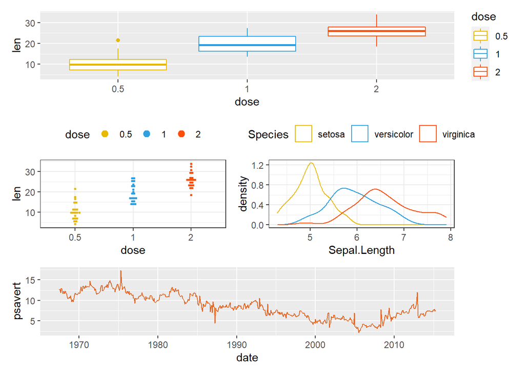

```r
(bxp + (dp + dens) + lp + plot_layout(ncol = 1)) * theme_gray()
```

whereas & will recurse into nested levels:

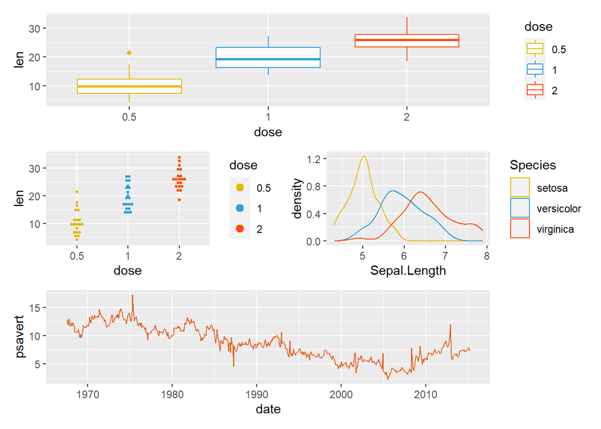

```r
(bxp + (dp + dens) + lp + plot_layout(ncol = 1)) & theme_gray()
```

# Ref

https://www.datanovia.com/en/blog/ggplot-multiple-plots-made-ridiculuous-simple-using-patchwork-r-package/